# Project Python 1 grapeq

Grape Quality Dataset Analysis - November 2024

The Grape Quality Dataset offers comprehensive information on the physical and chemical properties of grapes. This analysis is conducted using anonymized data sourced from different regions, grape varieties, and farming practices.The dataset provides detailed information about individual grape samples, including their unique identifier, variety, and geographic origin.

Objective: To explore the factors impacting grape quality, including physical attributes, ripeness levels, and environmental influences. The goal is to uncover key determinants of quality.

Data Sources:

- Grape quality indicators (e.g., weight, size)
- Environmental variables (e.g., soil moisture, rainfall, acidity)
- Data gathered from wine-producing regions such as France, Italy, USA and others

Importing all needed libraries:

```python
import pandas as pd
import numpy as np
import math
import matplotlib as plt
df = pd.read_csv("GRAPE_QUALITY.csv")
```

Data clean up-check for rows with NaN:

```python
df.info()
```

```
<class 'pandas.core.frame.DataFrame'>
RangeIndex: 1000 entries, 0 to 999
Data columns (total 13 columns):
 #   Column                 Non-Null Count  Dtype
---  ------                 --------------  -----
 0   sample_id              1000 non-null   int64
 1   variety                1000 non-null   object
 2   region                 1000 non-null   object
 3   quality_score          1000 non-null   float64
 4   quality_category       1000 non-null   object
 5   sugar_content_brix     1000 non-null   float64
 6   acidity_ph             1000 non-null   float64
 7   cluster_weight_g       1000 non-null   float64
 8   berry_size_mm          1000 non-null   float64
 9   harvest_date           1000 non-null   object
 10  sun_exposure_hours     1000 non-null   float64
 11  soil_moisture_percent  1000 non-null   float64
 12  rainfall_mm            1000 non-null   float64
dtypes: float64(8), int64(1), object(4)
memory usage: 101.7+ KB
```

installing plotly for future graphs:

```python
pip install plotly
```

```python
import plotly.express as px
import plotly.graph_objects as go
```

Descriptive statistics:

```python
fix_stats = df[['quality_score', 'sugar_content_brix', 'acidity_ph', 'cluster_weight_g', 'berry_size_mm', 'sun_exposure_hours',	'soil_moisture_percent','rainfall_mm']].describe().T[['mean', '50%', 'std']]
fix_stats.rename(columns={'50%': 'median'}, inplace=True)
fix_stats.head(10)
```

|  | mean | median | std |
| --- | --- | --- | --- |
| quality_score | 2.49436 | 2.500 | 0.528960 |
| sugar_content_brix | 20.14015 | 20.375 | 5.843944 |
| acidity_ph | 3.50341 | 3.500 | 0.406907 |
| cluster_weight_g | 197.11247 | 195.285 | 85.946831 |
| berry_size_mm | 17.41162 | 17.415 | 4.302279 |
| sun_exposure_hours | 8.99260 | 8.900 | 1.736462 |
| soil_moisture_percent | 49.73190 | 49.400 | 11.591189 |
| rainfall_mm | 489.42300 | 490.400 | 170.950250 |

Checking the right data type of all columns:

```python
if df['variety'].dtype != 'object':
    print("Warning: 'variety' column is not of type object.")
if df['region'].dtype != 'object':
    print("Warning: 'region' column is not of type object.")
if df['quality_category'].dtype != 'object':
    print("Warning: 'quality_category' column is not of type object.")
numeric_columns = ['quality_score', 'sugar_content_brix', 'acidity_ph',
                   'cluster_weight_g', 'berry_size_mm', 'sun_exposure_hours','soil_moisture_percent', 'rainfall_mm']
for col in numeric_columns:
    if not pd.api.types.is_float_dtype(df[col]):
        print(f"Warning: '{col}' column is not of type float.")
if df['harvest_date'].dtype != 'datetime64':
    print("Warning: 'harvest_date' column is not of type object.")
```

[output not shown]

```python
value_counts = df['quality_category'].value_counts()
plot_data = value_counts.reset_index()
plot_data.columns = ['quality_category', 'count']
figgg = px.pie(plot_data,
    names='quality_category',
    values='count',
    title='Grape Quality Categories',
    color='quality_category',
    color_discrete_map={'High': 'green', 'Medium': 'purple', 'Low': 'yellow'}
)
figgg
```

now let's see what is the most recent rounded quality score:

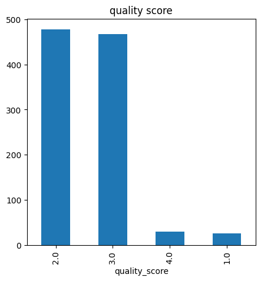

```python
df_r = df.round(0)
value_counts = df_r['quality_score'].value_counts()
value_counts.plot(kind='bar', title = 'quality score', figsize=(5, 5))
```

```python
pip install nbformat --upgrade
```

Hypothesis: Grape quality is influenced by a combination of environmental factors (e.g., acidity level, climate conditions) and intrinsic grape properties (e.g., sugar content, berry size, cluster weight), with optimal values of these factors correlating with higher quality scores.

To confirm the hypothesis we can notice interesting thing about the effect of sugar in grapes on its quality:

```python
px.scatter(df, x='sugar_content_brix', y='quality_score', labels={'x': 'Sugar', 'y': 'score'})
```

```python
fig = go.Figure()
for variety in df["variety"].unique():
    subset = df[df["variety"] == variety]
    fig.add_trace(
        go.Scatter(
            x=subset["sun_exposure_hours"],
            y=subset["quality_score"],
            mode="markers",
            name=variety,
            marker=dict(size=subset["berry_size_mm"], opacity=0.7),
        )
    )

fig.update_layout(
    title="Grape Quality Analysis: Sun Exposure vs Quality Score",
    xaxis=dict(title="Sun Exposure (Hours)", showgrid=True),
    yaxis=dict(title="Quality Score", showgrid=True),
    legend_title_text="Variety",
    plot_bgcolor="white",
)
```

The next step is to find out how the amount of rainfall affects the quality of the grapes:

```python
fik = px.density_contour(df, x="rainfall_mm", y="quality_score")
fik.update_traces(contours_coloring="fill", contours_showlabels = True)
fik
```

```python
pip install statsmodels
```

```python
fis = px.scatter(df, x="quality_score", y="acidity_ph", trendline="ols")
fis
```

```python
fig = px.density_heatmap(df, x = "cluster_weight_g"	, y="berry_size_mm", z="quality_score", color_continuous_scale='Viridis')
fig
```

```python
fig2 = px.scatter_3d(df, x = "soil_moisture_percent", y="sun_exposure_hours", z="quality_score", color='variety', opacity=0.7)
fig2
```

Conclusion on the Hypotheses: Quality Score Analysis of Grapes: Based on the analysis, it was observed that most factors significantly influence the quality score of grapes, except for soil moisture and acidity (pH) , which showed little to no measurable impact in the dataset.

Now I want to know, where do the best grapes grow?

To discover it, I need to add additional column, where region transformed to countries:

```python
region_counts = df["region"].value_counts()
region_counts
```

```
region
Napa Valley       137
Barossa Valley    136
Bordeaux          133
Mendoza           130
Sonoma            127
Loire Valley      126
Rioja             107
Tuscany           104
Name: count, dtype: int64
```

```python
region_to_country = {
    "Napa Valley": "USA",
"Barossa Valley": "AUS",
"Bordeaux": "FRA",
"Mendoza": "ARG",
"Sonoma": "USA",
"Loire Valley": "FRA",
"Rioja": "ESP",
"Tuscany": "ITA"
}
df["country_p"] = df["region"].map(region_to_country)
df
```

|  | sample_id | variety | region | quality_score | quality_category | sugar_content_brix | acidity_ph | cluster_weight_g | berry_size_mm | harvest_date | sun_exposure_hours | soil_moisture_percent | rainfall_mm | country_p |
| --- | --- | --- | --- | --- | --- | --- | --- | --- | --- | --- | --- | --- | --- | --- |
| 0 | 1 | Riesling | Barossa Valley | 2.11 | Medium | 13.70 | 3.17 | 251.81 | 18.58 | 2023-09-04 | 8.4 | 55.9 | 223.3 | AUS |
| 1 | 2 | Pinot Noir | Loire Valley | 2.83 | High | 20.84 | 3.15 | 289.00 | 22.08 | 2023-09-16 | 8.8 | 36.9 | 312.1 | FRA |
| 2 | 3 | Sauvignon Blanc | Napa Valley | 3.52 | Premium | 27.46 | 4.07 | 125.14 | 21.40 | 2023-08-25 | 11.1 | 64.9 | 698.7 | USA |
| 3 | 4 | Riesling | Napa Valley | 2.28 | Medium | 24.64 | 3.15 | 237.46 | 12.31 | 2023-09-13 | 8.0 | 54.5 | 660.1 | USA |
| 4 | 5 | Merlot | Napa Valley | 2.90 | High | 26.13 | 3.18 | 221.52 | 12.24 | 2023-08-11 | 11.2 | 36.3 | 410.4 | USA |
| ... | ... | ... | ... | ... | ... | ... | ... | ... | ... | ... | ... | ... | ... | ... |
| 995 | 996 | Sauvignon Blanc | Napa Valley | 3.14 | High | 23.14 | 4.01 | 182.63 | 23.46 | 2023-09-09 | 10.1 | 53.2 | 363.9 | USA |
| 996 | 997 | Cabernet Sauvignon | Sonoma | 2.65 | High | 29.13 | 3.02 | 150.32 | 11.79 | 2023-08-19 | 9.0 | 56.7 | 325.7 | USA |
| 997 | 998 | Pinot Noir | Napa Valley | 2.11 | Medium | 11.38 | 3.23 | 168.37 | 14.92 | 2023-08-28 | 10.6 | 66.5 | 473.2 | USA |
| 998 | 999 | Zinfandel | Loire Valley | 2.28 | Medium | 11.14 | 3.21 | 208.98 | 22.24 | 2023-08-24 | 8.9 | 43.8 | 745.1 | FRA |
| 999 | 1000 | Merlot | Napa Valley | 1.96 | Medium | 15.64 | 4.02 | 98.41 | 18.96 | 2023-08-29 | 6.9 | 54.9 | 262.7 | USA |

1000 rows × 14 columns

```python
pdf = df.copy()
for country_p in pdf['country_p'].unique():
    pdf.loc[pdf['country_p'] == country_p, :] = pdf.loc[pdf['country_p'] == country_p, :].fillna(method='ffill').fillna(0)
```

```python
fig5 = px.choropleth(
    pdf,
    locations="country_p",
    color="quality_score",
    hover_name="country_p",
    color_continuous_scale='viridis',
    projection="natural earth",
    range_color=[0, 4],
    title="Grape Quality Analysis: Geographical position vs Quality Score",
)

fig5
```

So the best grapes grow in the USA:

```python
from urllib.request import urlopen
import json
with urlopen('https://raw.githubusercontent.com/plotly/datasets/master/geojson-counties-fips.json') as response:
    counties = json.load(response)
list_state = ['CA']
figg = px.choropleth(geojson=counties, color=[3.52], range_color=([0, 5]),
                           color_continuous_scale='Viridis',
                           locationmode="USA-states",
                           locations=['CA'],
                           scope="usa"
                          )
figg
```

As we can see grapes are growing in the only state Califonia

Now let's add the column, which summarizing quality score, sun exposure and sugar content, as their sum will show us the best sorts:

```python
df['qss_sum'] = ( df['quality_score'] + df['sugar_content_brix'] + df['sun_exposure_hours'])
df
```

|  | sample_id | variety | region | quality_score | quality_category | sugar_content_brix | acidity_ph | cluster_weight_g | berry_size_mm | harvest_date | sun_exposure_hours | soil_moisture_percent | rainfall_mm | country_p | qss_sum |
| --- | --- | --- | --- | --- | --- | --- | --- | --- | --- | --- | --- | --- | --- | --- | --- |
| 0 | 1 | Riesling | Barossa Valley | 2.11 | Medium | 13.70 | 3.17 | 251.81 | 18.58 | 2023-09-04 | 8.4 | 55.9 | 223.3 | AUS | 24.21 |
| 1 | 2 | Pinot Noir | Loire Valley | 2.83 | High | 20.84 | 3.15 | 289.00 | 22.08 | 2023-09-16 | 8.8 | 36.9 | 312.1 | FRA | 32.47 |
| 2 | 3 | Sauvignon Blanc | Napa Valley | 3.52 | Premium | 27.46 | 4.07 | 125.14 | 21.40 | 2023-08-25 | 11.1 | 64.9 | 698.7 | USA | 42.08 |
| 3 | 4 | Riesling | Napa Valley | 2.28 | Medium | 24.64 | 3.15 | 237.46 | 12.31 | 2023-09-13 | 8.0 | 54.5 | 660.1 | USA | 34.92 |
| 4 | 5 | Merlot | Napa Valley | 2.90 | High | 26.13 | 3.18 | 221.52 | 12.24 | 2023-08-11 | 11.2 | 36.3 | 410.4 | USA | 40.23 |
| ... | ... | ... | ... | ... | ... | ... | ... | ... | ... | ... | ... | ... | ... | ... | ... |
| 995 | 996 | Sauvignon Blanc | Napa Valley | 3.14 | High | 23.14 | 4.01 | 182.63 | 23.46 | 2023-09-09 | 10.1 | 53.2 | 363.9 | USA | 36.38 |
| 996 | 997 | Cabernet Sauvignon | Sonoma | 2.65 | High | 29.13 | 3.02 | 150.32 | 11.79 | 2023-08-19 | 9.0 | 56.7 | 325.7 | USA | 40.78 |
| 997 | 998 | Pinot Noir | Napa Valley | 2.11 | Medium | 11.38 | 3.23 | 168.37 | 14.92 | 2023-08-28 | 10.6 | 66.5 | 473.2 | USA | 24.09 |
| 998 | 999 | Zinfandel | Loire Valley | 2.28 | Medium | 11.14 | 3.21 | 208.98 | 22.24 | 2023-08-24 | 8.9 | 43.8 | 745.1 | FRA | 22.32 |
| 999 | 1000 | Merlot | Napa Valley | 1.96 | Medium | 15.64 | 4.02 | 98.41 | 18.96 | 2023-08-29 | 6.9 | 54.9 | 262.7 | USA | 24.50 |

1000 rows × 15 columns

So it is interesting to see the best grapes in the whole world and notice which of them from USA:

```python
df_top = df.sort_values(by='qss_sum', ascending=False)
df_top.head(20)
df = df.drop_duplicates()
```

```python
cvk = df_top['country_p'].head(20)
usa = cvk.value_counts().get('USA', 0)
usa
```

```
np.int64(9)
```

We see that out of 20 best grape countries - USA appears 9 times, it is almost a half!

The project successfully identified actionable insights into the drivers of grape quality, supporting vineyards in optimizing growing conditions and improving operations. The findings can guide strategies for enhancing grape production, achieving sustainability, and maximizing the quality of output.